# Assignment 2

Yuqiang Wang & Zhenqiang Xu & Yuriy A Podvysotskiy

2017/9/22

# HW2

# Author: YUW99 & ZHX31 & YAP7

# Task 1

**response variable: TARGET_Adjusted and RISK_Adjustment**

**predictors: the other features(Age,Employment,Education,Marital,Occupation,Income,Gender,Deductions,Hours,ID)**

# Task 2

Explore the dataset, and generate both statistical and graphical summary with respect to the numerical and categorical variables. Provide analysis similar to HW1 (2b)–(2e)..

### (a) Summary Table

```r
#dataset path
audit <- "/Users/zhenqiang/Downloads/audit.csv"
#load the dataset
dataset <- read.csv(audit,1,stringsAsFactors = FALSE)
summary(dataset)
```

```
##        ID               Age         Employment         Education
##  Min.   :1004641   Min.   :17.00   Length:2000        Length:2000
##  1st Qu.:3437052   1st Qu.:28.00   Class :character   Class :character
##  Median :5638451   Median :37.00   Mode  :character   Mode  :character
##  Mean   :5624348   Mean   :38.62
##  3rd Qu.:7876535   3rd Qu.:48.00
##  Max.   :9996101   Max.   :90.00
##    Marital           Occupation            Income
##  Length:2000        Length:2000        Min.   :   609.7
##  Class :character   Class :character   1st Qu.: 34433.1
##  Mode  :character   Mode  :character   Median : 59768.9
##                                        Mean   : 84688.5
##                                        3rd Qu.:113842.9
##                                        Max.   :481259.5
##     Gender            Deductions          Hours       RISK_Adjustment
##  Length:2000        Min.   :   0.00   Min.   : 1.00   Min.   : -1453
##  Class :character   1st Qu.:   0.00   1st Qu.:38.00   1st Qu.:     0
##  Mode  :character   Median :   0.00   Median :40.00   Median :     0
##                     Mean   :  67.57   Mean   :40.07   Mean   :  2021
##                     3rd Qu.:   0.00   3rd Qu.:45.00   3rd Qu.:     0
##                     Max.   :2904.00   Max.   :99.00   Max.   :112243
##  TARGET_Adjusted
##  Min.   :0.0000
##  1st Qu.:0.0000
##  Median :0.0000
##  Mean   :0.2315
##  3rd Qu.:0.0000
##  Max.   :1.0000
```

```
From the dataset summary, we found out seven numerical variables include 'ID','Age','Income','Deductions','Hours', 'RISK_Adjustment', and 'TARGET_Adjusted'. And five categorical vairables include Employment, Education, Marital, and Gender.
```

```r
#check misssing value
apply(is.na(dataset),2,sum)
```

```
##              ID             Age      Employment       Education
##               0               0             100               0
##         Marital      Occupation          Income          Gender
##               0             101               0               0
##      Deductions           Hours RISK_Adjustment TARGET_Adjusted
##               0               0               0               0
```

```r
#Remove the row that contains missing values
dataset<-dataset[complete.cases(dataset), ]
apply(is.na(dataset),2,sum)
```

```
##              ID             Age      Employment       Education
##               0               0               0               0
##         Marital      Occupation          Income          Gender
##               0               0               0               0
##      Deductions           Hours RISK_Adjustment TARGET_Adjusted
##               0               0               0               0
```

```r
numericalDF <- data.frame("Age"=dataset$Age,"Income"=dataset$Income,"Deductions"=dataset$Deductions,"Hours"=dataset$Hours, "RISK_Adjustment"=dataset$RISK_Adjustment,"TARGET_Adjusted"=dataset$TARGET_Adjusted)
#install.packages("fBasics")
library(fBasics)
basicStats(numericalDF)[c("Minimum","Maximum","Mean","Median","1. Quartile","3. Quartile","Stdev"),]
```

```
##                  Age    Income Deductions    Hours RISK_Adjustment
## Minimum     17.00000    609.72    0.00000  1.00000       -1453.000
## Maximum     83.00000 481259.50 2824.00000 99.00000      112243.000
## Mean        38.30279  84404.87   68.65964 40.56714        2025.257
## Median      37.00000  59534.87    0.00000 40.00000           0.000
## 1. Quartile 28.00000  33987.24    0.00000 40.00000           0.000
## 3. Quartile 47.00000 113331.15    0.00000 45.00000           0.000
## Stdev       13.01375  69688.98  340.74686 11.65933        8227.082
##             TARGET_Adjusted
## Minimum            0.000000
## Maximum            1.000000
## Mean               0.235387
## Median             0.000000
## 1. Quartile        0.000000
## 3. Quartile        0.000000
## Stdev              0.424352
```

### (b) Density Distribution

```r
library(ggplot2)
library(e1071)
shapiro.test(numericalDF$Age)
```

```
##
##  Shapiro-Wilk normality test
##
## data:  numericalDF$Age
## W = 0.96986, p-value < 2.2e-16
```

```r
skewness(numericalDF$Age)
```

```
## [1] 0.4676669
```

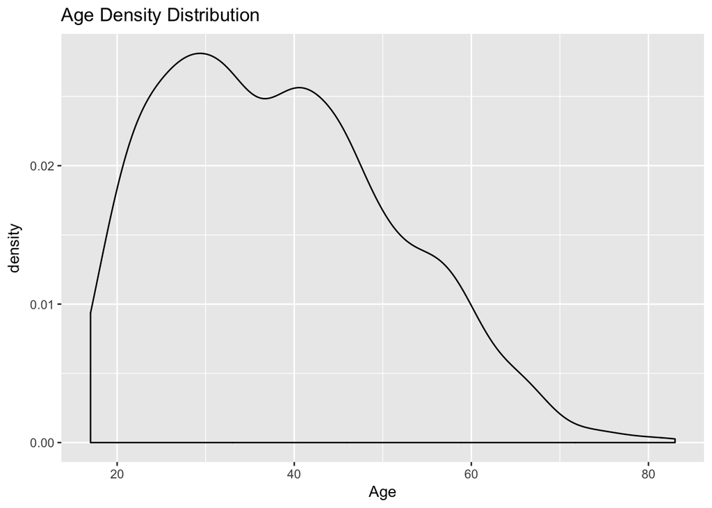

```r
ggplot(numericalDF, aes(x = Age)) + geom_density() + labs(title = "Age Density Distribution")
```

```r
shapiro.test(numericalDF$Income)
```

```
##
##  Shapiro-Wilk normality test
##
## data:  numericalDF$Income
## W = 0.84847, p-value < 2.2e-16
```

```r
skewness(numericalDF$Income)
```

```
## [1] 1.503573
```

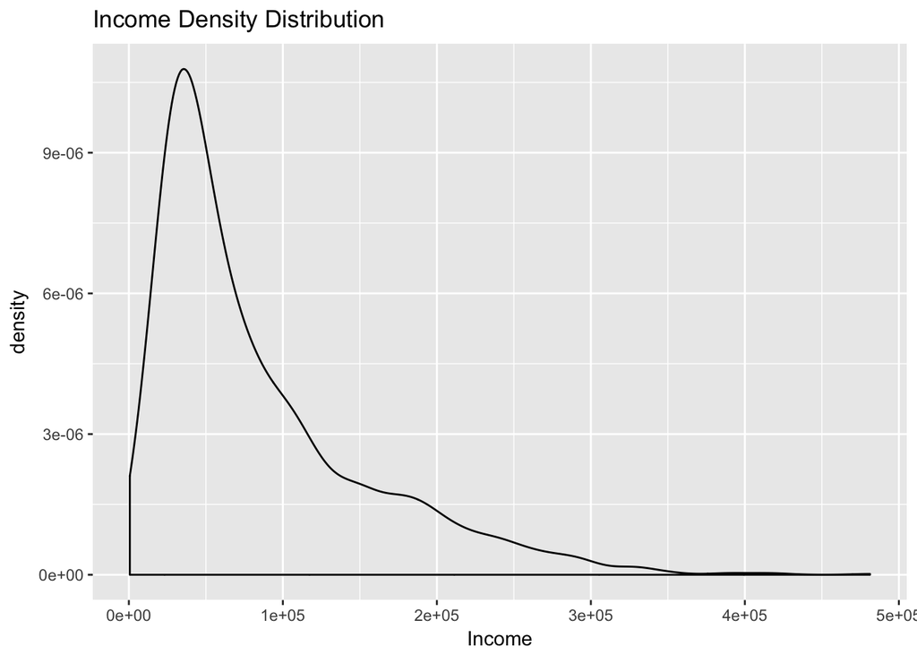

```r
ggplot(numericalDF, aes(x = Income)) + geom_density() + labs(title = "Income Density Distribution")
```

```r
shapiro.test(numericalDF$Deductions)
```

```
##
##  Shapiro-Wilk normality test
##
## data:  numericalDF$Deductions
## W = 0.20199, p-value < 2.2e-16
```

```r
skewness(numericalDF$Deductions)
```

```
## [1] 5.138524
```

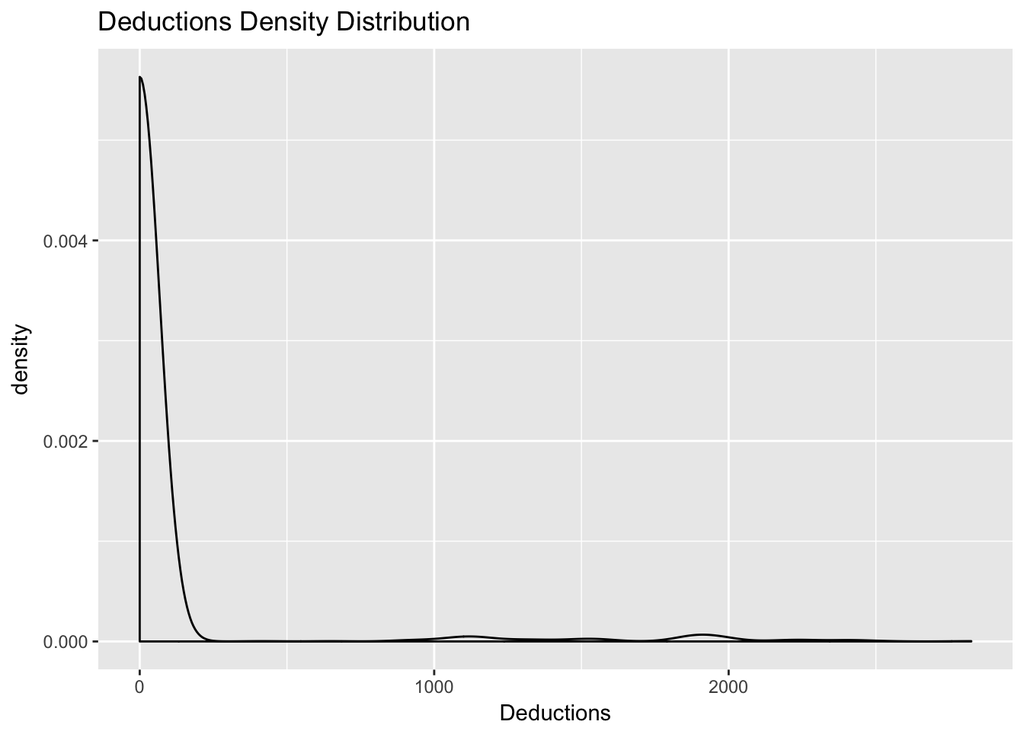

```r
ggplot(numericalDF, aes(x = Deductions)) + geom_density() + labs(title = "Deductions Density Distribution")
```

```r
shapiro.test(numericalDF$Hours)
```

```
##
##  Shapiro-Wilk normality test
##
## data:  numericalDF$Hours
## W = 0.88881, p-value < 2.2e-16
```

```r
skewness(numericalDF$Hours)
```

```
## [1] 0.281257
```

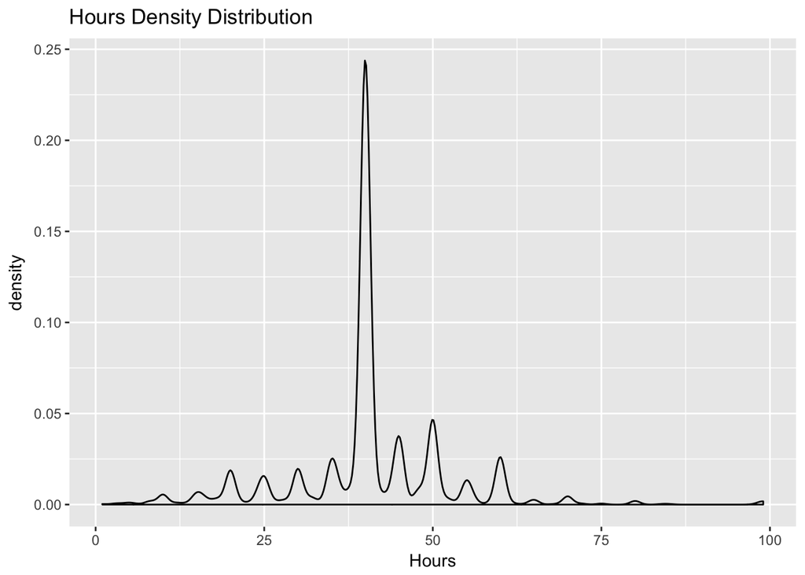

```r
ggplot(numericalDF, aes(x = Hours)) + geom_density() + labs(title = "Hours Density Distribution")
```

```r
shapiro.test(numericalDF$RISK_Adjustment)
```

```
##
##  Shapiro-Wilk normality test
##
## data:  numericalDF$RISK_Adjustment
## W = 0.23509, p-value < 2.2e-16
```

```r
skewness(numericalDF$RISK_Adjustment)
```

```
## [1] 9.633048
```

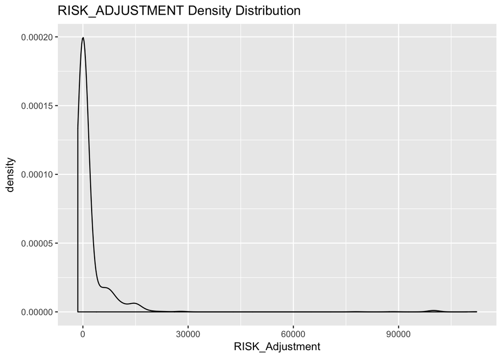

```r
ggplot(numericalDF, aes(x = RISK_Adjustment)) + geom_density() + labs(title = "RISK_ADJUSTMENT Density Distribution")
```

```r
shapiro.test(numericalDF$TARGET_Adjusted)
```

```
##
##  Shapiro-Wilk normality test
##
## data:  numericalDF$TARGET_Adjusted
## W = 0.52561, p-value < 2.2e-16
```

```r
skewness(numericalDF$TARGET_Adjusted)
```

```
## [1] 1.246482
```

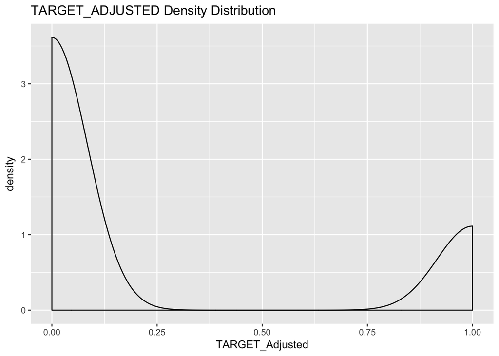

```r
ggplot(numericalDF, aes(x = TARGET_Adjusted)) + geom_density() + labs(title = "TARGET_ADJUSTED Density Distribution")
```

For normal distribution, we used shapiro.test function to test p-value. If p-value is larger than 0.05 that means the variable is normal distribution. For skew distribution, we used skewness function to test the positive or negative result to determine left skew distribution or right skew distribution. Meanwhile, we also can distinguish normal and skew distribution by the graphic analysis. As a result, the variables: Age, Income, Dectuctions, Hours, and RISK_Adjustment are right skew distribution. Target_Adjusted is neither normal distribution nor skew distribution.

### (c) Conditional Histogram

### Plot Conditional Histogram for Target_Adjusted Response Variable with Categorical Variable

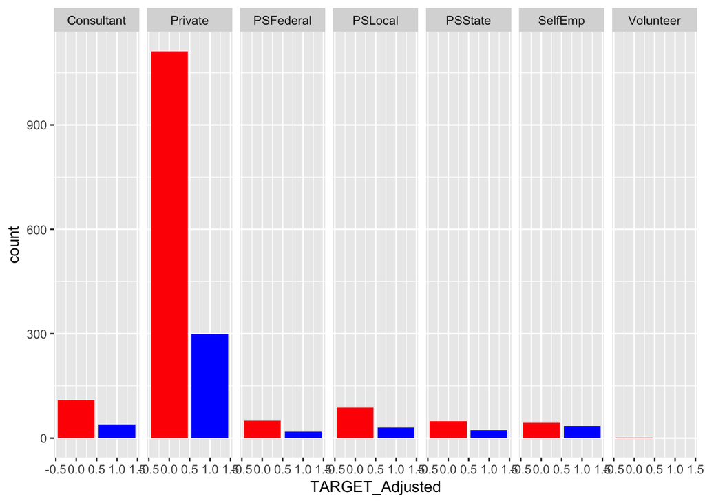

```r
ggplot(data = dataset, aes(x = TARGET_Adjusted)) + geom_bar(data=subset(dataset,TARGET_Adjusted==0),fill="red") +geom_bar(data=subset(dataset,TARGET_Adjusted==1),fill="blue")+ facet_wrap(~Employment,nrow = 1)
```

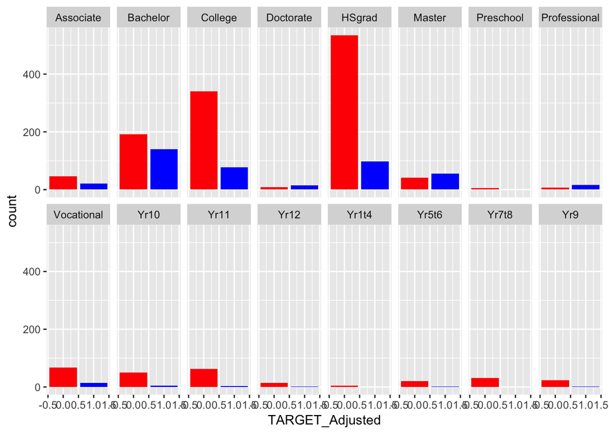

```r
ggplot(data = dataset, aes(x = TARGET_Adjusted)) + geom_bar(data=subset(dataset,TARGET_Adjusted==0),fill="red") +geom_bar(data=subset(dataset,TARGET_Adjusted==1),fill="blue")+ facet_wrap(~Education,nrow = 2)
```

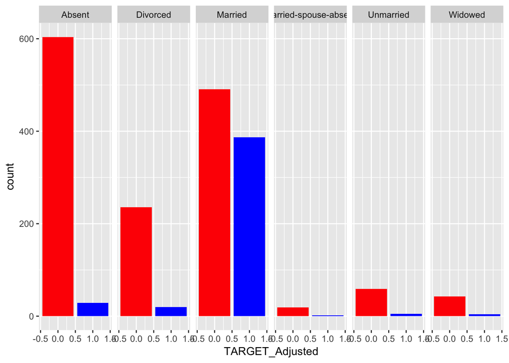

```r
ggplot(data = dataset, aes(x = TARGET_Adjusted)) + geom_bar(data=subset(dataset,TARGET_Adjusted==0),fill="red") +geom_bar(data=subset(dataset,TARGET_Adjusted==1),fill="blue")+ facet_wrap(~Marital,nrow = 1)
```

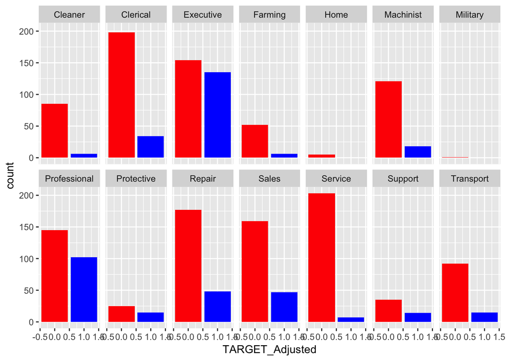

```r
ggplot(data = dataset, aes(x = TARGET_Adjusted)) + geom_bar(data=subset(dataset,TARGET_Adjusted==0),fill="red") +geom_bar(data=subset(dataset,TARGET_Adjusted==1),fill="blue")+ facet_wrap(~Occupation,nrow = 2)
```

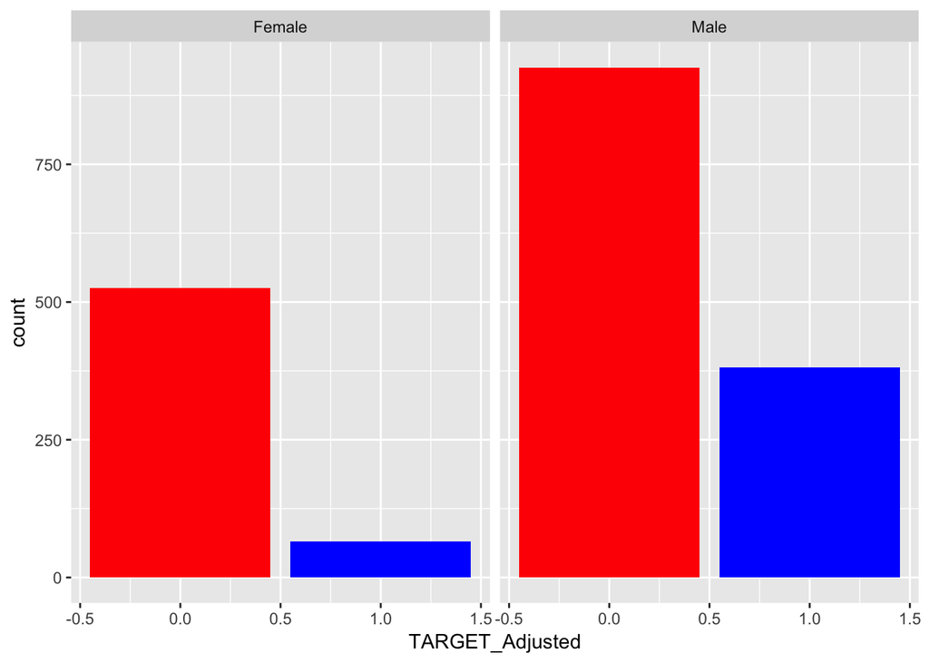

```r
ggplot(data = dataset, aes(x = TARGET_Adjusted)) + geom_bar(data=subset(dataset,TARGET_Adjusted==0),fill="red") +geom_bar(data=subset(dataset,TARGET_Adjusted==1),fill="blue")+ facet_wrap(~Gender,nrow = 1)
```

### Plot Conditional Histogram for Risk_Adjustment Response Variable with Categorical Variable

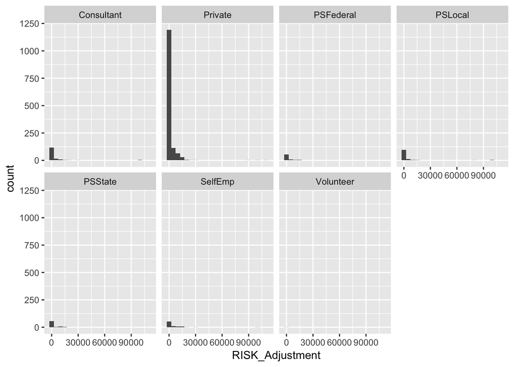

```r
ggplot(data = dataset, aes(x = RISK_Adjustment)) + geom_histogram(binwidth = 5000)+ facet_wrap(~Employment,nrow = 2)
```

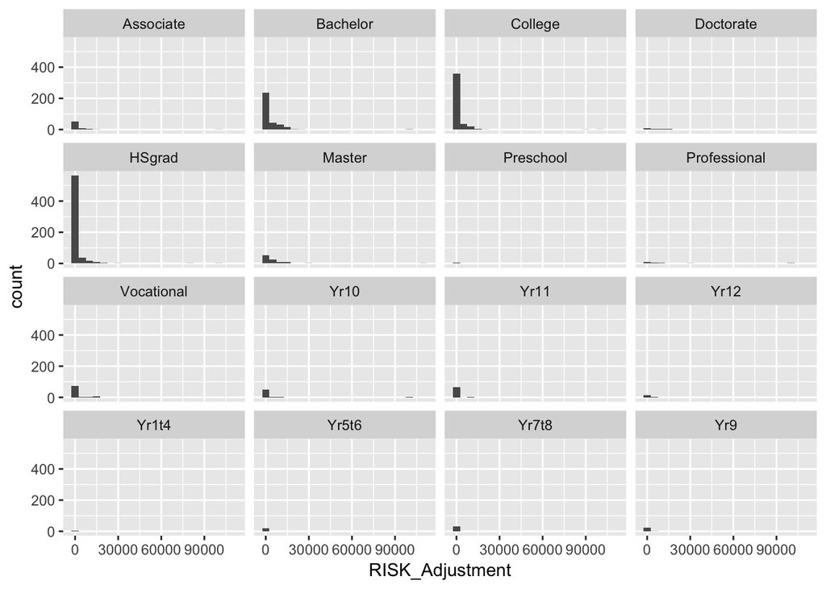

```r
ggplot(data = dataset, aes(x = RISK_Adjustment)) + geom_histogram(binwidth = 5000)+ facet_wrap(~Education,nrow = 4)
```

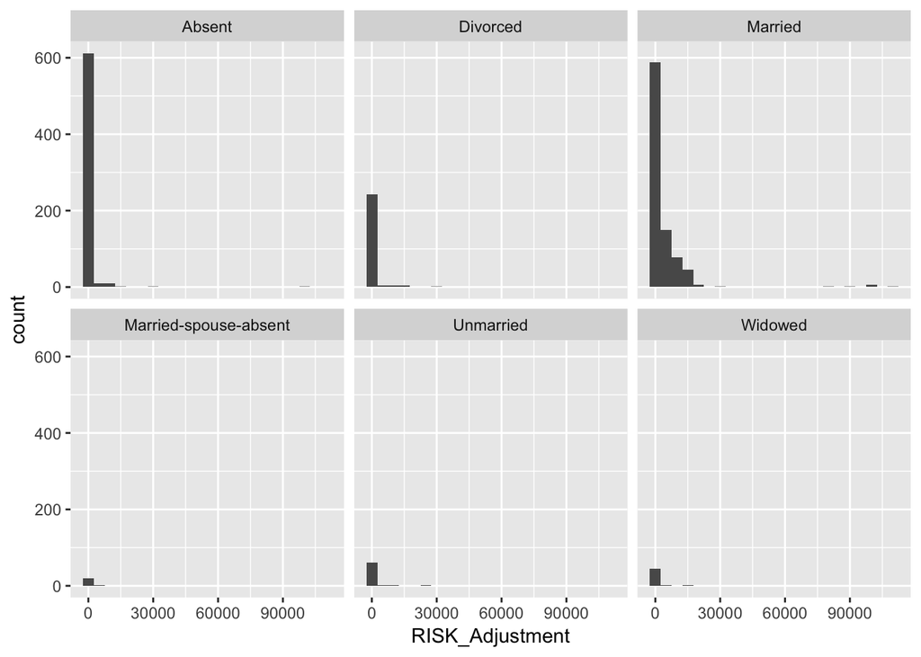

```r
ggplot(data = dataset, aes(x = RISK_Adjustment)) + geom_histogram(binwidth = 5000)+ facet_wrap(~Marital,nrow = 2)
```

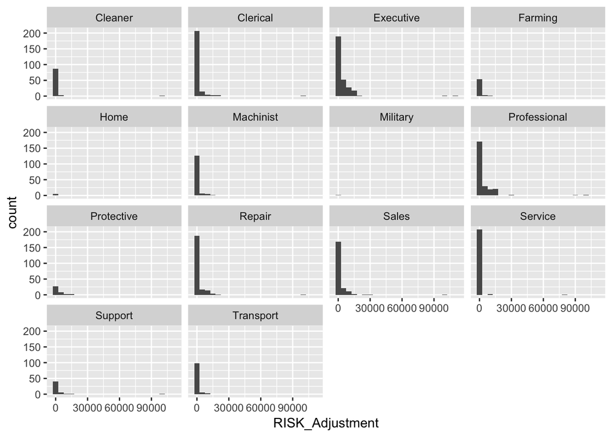

```r
ggplot(data = dataset, aes(x = RISK_Adjustment)) + geom_histogram(binwidth = 5000)+ facet_wrap(~Occupation,nrow = 4)
```

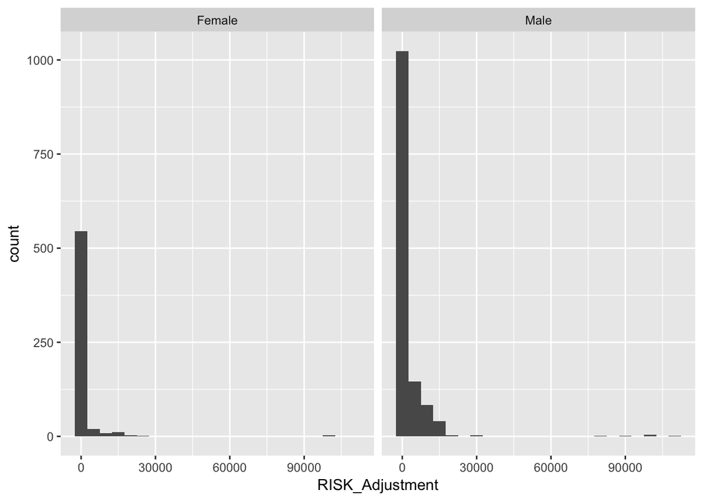

```r
ggplot(data = dataset, aes(x = RISK_Adjustment)) + geom_histogram(binwidth = 5000)+ facet_wrap(~Gender,nrow = 1)
```

# Task 3

Apply logistic regression analysis to predict TARGET_Adjusted. Evaluate the models through cross-validation and on holdout samples. Interpret the effect of the predictors.

–a) Implement a 10-fold cross-validation scheme by splitting the data into training and testing sets. Use the training set to train a logistic regressionmodeltopredicttheresponsevariable.Examinethe performance of different models by varying the number of predictors. Report the performance of the models on testing set using proper measures (accuracy, precision, recall, F1, AUC) and plots (ROC, lift).

–b) For the best model, compute the odds ratio and interpret the effect of each predictors.

```r
'Q3 - Logistic model'
```

```
## [1] "Q3 - Logistic model"
```

```r
'--------------------------------------'
```

```
## [1] "--------------------------------------"
```

```r
rm(list=ls())
# setwd("/Users/zhenqiang/Downloads/audit.csv")
audit<- read.csv2("/Users/zhenqiang/Downloads/audit.csv", sep=",", dec=".")

audit<-audit[complete.cases(audit), ]# delete the NA values
rownames(audit)<-1:nrow(audit)# rename rownames

# delete two special data
audit <- audit[-62,]
rownames(audit)<-1:nrow(audit)# rename rownames

audit <- audit[-931,]
```

```r
audit[1:3,]
```

```
##        ID Age Employment Education   Marital Occupation   Income Gender
## 1 1004641  38    Private   College Unmarried    Service  81838.0 Female
## 2 1010229  35    Private Associate    Absent  Transport  72099.0   Male
## 3 1024587  32    Private    HSgrad  Divorced   Clerical 154676.7   Male
##   Deductions Hours RISK_Adjustment TARGET_Adjusted
## 1          0    72               0               0
## 2          0    30               0               0
## 3          0    40               0               0
```

```r
summary(audit)
```

```
##        ID               Age            Employment        Education
##  Min.   :1004641   Min.   :17.0   Private   :1411   HSgrad    :633
##  1st Qu.:3399879   1st Qu.:28.0   Consultant: 148   College   :417
##  Median :5634257   Median :37.0   PSLocal   : 119   Bachelor  :332
##  Mean   :5600208   Mean   :38.3   SelfEmp   :  79   Master    : 98
##  3rd Qu.:7858910   3rd Qu.:47.0   PSState   :  72   Vocational: 81
##  Max.   :9996101   Max.   :83.0   PSFederal :  68   Associate : 66
##                                   (Other)   :   0   (Other)   :270
##                   Marital           Occupation      Income
##  Absent               :632   Executive   :289   Min.   :   609.7
##  Divorced             :256   Professional:247   1st Qu.: 33987.2
##  Married              :877   Clerical    :232   Median : 59534.9
##  Married-spouse-absent: 21   Repair      :225   Mean   : 84411.6
##  Unmarried            : 64   Service     :210   3rd Qu.:113425.7
##  Widowed              : 47   Sales       :206   Max.   :481259.5
##                              (Other)     :488
##     Gender       Deductions          Hours       RISK_Adjustment
##  Female: 592   Min.   :   0.00   Min.   : 1.00   Min.   : -1453
##  Male  :1305   1st Qu.:   0.00   1st Qu.:40.00   1st Qu.:     0
##                Median :   0.00   Median :40.00   Median :     0
##                Mean   :  68.73   Mean   :40.56   Mean   :  2027
##                3rd Qu.:   0.00   3rd Qu.:45.00   3rd Qu.:     0
##                Max.   :2824.00   Max.   :99.00   Max.   :112243
##
##  TARGET_Adjusted
##  Min.   :0.0000
##  1st Qu.:0.0000
##  Median :0.0000
##  Mean   :0.2356
##  3rd Qu.:0.0000
##  Max.   :1.0000
##
```

```r
summary(audit$Occupation[is.na(audit$Employment)])
```

```
##      Cleaner     Clerical    Executive      Farming         Home
##            0            0            0            0            0
##    Machinist     Military Professional   Protective       Repair
##            0            0            0            0            0
##        Sales      Service      Support    Transport
##            0            0            0            0
```

```r
'NAs available for: Employment and Occupation. These are unemployed'
```

```
## [1] "NAs available for: Employment and Occupation. These are unemployed"
```

```r
mm1<-glm(TARGET_Adjusted~Age+Employment+Education+Marital+Occupation+Income+Gender+Deductions+Hours,
        family=binomial(link="logit"),data=audit)
summary(mm1)
```

```
##
## Call:
## glm(formula = TARGET_Adjusted ~ Age + Employment + Education +
##     Marital + Occupation + Income + Gender + Deductions + Hours,
##     family = binomial(link = "logit"), data = audit)
##
## Deviance Residuals:
##      Min        1Q    Median        3Q       Max
## -2.61706  -0.53467  -0.22271  -0.00019   2.88516
##
## Coefficients:
##                                Estimate Std. Error z value Pr(>|z|)
## (Intercept)                  -6.714e+00  8.470e-01  -7.926 2.26e-15 ***
## Age                           2.976e-02  6.736e-03   4.418 9.98e-06 ***
## EmploymentPrivate             3.483e-01  2.554e-01   1.364  0.17264
## EmploymentPSFederal           3.052e-01  4.224e-01   0.723  0.46988
## EmploymentPSLocal             1.047e-01  3.890e-01   0.269  0.78772
## EmploymentPSState             3.177e-01  4.349e-01   0.730  0.46514
## EmploymentSelfEmp             1.404e-01  3.695e-01   0.380  0.70387
## EducationBachelor             5.568e-02  3.675e-01   0.152  0.87956
## EducationCollege             -8.533e-01  3.698e-01  -2.307  0.02104 *
## EducationDoctorate            9.705e-01  6.650e-01   1.459  0.14446
## EducationHSgrad              -1.120e+00  3.632e-01  -3.083  0.00205 **
## EducationMaster               4.906e-01  4.511e-01   1.087  0.27682
## EducationPreschool           -1.558e+01  1.406e+03  -0.011  0.99116
## EducationProfessional         1.691e+00  6.632e-01   2.550  0.01076 *
## EducationVocational          -1.030e+00  4.900e-01  -2.102  0.03559 *
## EducationYr10                -1.532e+00  6.611e-01  -2.317  0.02051 *
## EducationYr11                -1.491e+00  7.381e-01  -2.020  0.04341 *
## EducationYr12                -1.705e+00  1.196e+00  -1.426  0.15384
## EducationYr1t4               -1.734e+01  1.719e+03  -0.010  0.99195
## EducationYr5t6               -2.848e+00  1.178e+00  -2.418  0.01562 *
## EducationYr7t8               -1.667e+01  6.097e+02  -0.027  0.97819
## EducationYr9                 -2.921e+00  1.136e+00  -2.570  0.01017 *
## MaritalDivorced              -4.271e-02  3.398e-01  -0.126  0.90000
## MaritalMarried                2.696e+00  2.431e-01  11.087  < 2e-16 ***
## MaritalMarried-spouse-absent  4.531e-01  8.214e-01   0.552  0.58127
## MaritalUnmarried              6.129e-01  5.417e-01   1.131  0.25793
## MaritalWidowed                1.336e-01  6.532e-01   0.205  0.83791
## OccupationClerical            1.188e+00  5.308e-01   2.239  0.02517 *
```

[output cut: 10 more lines]

```
## OccupationTransport           2.492e-01  5.561e-01   0.448  0.65402
## Income                        2.504e-06  1.462e-06   1.713  0.08670 .
## GenderMale                    1.967e-01  2.505e-01   0.785  0.43247
## Deductions                    1.106e-03  2.071e-04   5.340 9.27e-08 ***
## Hours                         3.623e-02  6.823e-03   5.311 1.09e-07 ***
## ---
## Signif. codes:  0 '***' 0.001 '**' 0.01 '*' 0.05 '.' 0.1 ' ' 1
##
## (Dispersion parameter for binomial family taken to be 1)
##
##     Null deviance: 2071.5  on 1896  degrees of freedom
## Residual deviance: 1276.2  on 1854  degrees of freedom
## AIC: 1362.2
##
## Number of Fisher Scoring iterations: 16
```

```r
mm2 <- glm(TARGET_Adjusted~Age+Education+Marital+Occupation+Income+Deductions+Hours,
          family=binomial(link="logit"),data=audit)

mm3 <- glm(TARGET_Adjusted~log(Age)+Education+Marital+Occupation+log(Income)+Deductions+log(Hours),
          family=binomial(link="logit"),data=audit)

'(*) Estimating and initial performance analysis:'
```

```
## [1] "(*) Estimating and initial performance analysis:"
```

```r
'Split into training and testing:'
```

```
## [1] "Split into training and testing:"
```

```r
audit1<-audit
audit1$RISK_Adjustment<- NULL

audit2<-audit1
audit2$Employment <-NULL
audit2$Gender <-NULL

audit3<-audit2
audit3$Age <- log(audit2$Age)
audit3$Income <- log(audit2$Income)
audit3$Hours <- log(audit2$Hours)

audit1[1:3,]
```

```
##        ID Age Employment Education   Marital Occupation   Income Gender
## 1 1004641  38    Private   College Unmarried    Service  81838.0 Female
## 2 1010229  35    Private Associate    Absent  Transport  72099.0   Male
## 3 1024587  32    Private    HSgrad  Divorced   Clerical 154676.7   Male
##   Deductions Hours TARGET_Adjusted
## 1          0    72               0
## 2          0    30               0
## 3          0    40               0
```

```r
audit2[1:3,]
```

```
##        ID Age Education   Marital Occupation   Income Deductions Hours
## 1 1004641  38   College Unmarried    Service  81838.0          0    72
## 2 1010229  35 Associate    Absent  Transport  72099.0          0    30
## 3 1024587  32    HSgrad  Divorced   Clerical 154676.7          0    40
##   TARGET_Adjusted
## 1               0
## 2               0
## 3               0
```

```r
audit3[1:3,]
```

```
##        ID      Age Education   Marital Occupation   Income Deductions
## 1 1004641 3.637586   College Unmarried    Service 11.31250          0
## 2 1010229 3.555348 Associate    Absent  Transport 11.18580          0
## 3 1024587 3.465736    HSgrad  Divorced   Clerical 11.94909          0
##      Hours TARGET_Adjusted
## 1 4.276666               0
## 2 3.401197               0
## 3 3.688879               0
```

```r
n.total = length(audit1$ID)
n.total
```

```
## [1] 1897
```

```r
n.train =floor(n.total*0.8)
n.train
```

```
## [1] 1517
```

```r
n.test=n.total - n.train

Xaudit1 <- audit1[,c(2:10)]
Xaudit2 <- audit2[,c(2:8)]
Xaudit3 <- audit3[,c(2:8)]

train=sample(1:n.total, n.train)
xtrain1 = Xaudit1[train,]
xtrain2 = Xaudit2[train,]
xtrain3 = Xaudit3[train,]

xtest1 = Xaudit1[-train,]
xtest2 = Xaudit2[-train,]
xtest3 = Xaudit3[-train,]

ytrain = audit$TARGET_Adjusted[train]
ytest = audit$TARGET_Adjusted[-train]
m1<- glm(TARGET~., family=binomial,data=data.frame(TARGET=ytrain,xtrain1))
m2<- glm(TARGET~., family=binomial,data=data.frame(TARGET=ytrain,xtrain2))
m3<- glm(TARGET~., family=binomial,data=data.frame(TARGET=ytrain,xtrain3))
ptest1 = predict(m1, newdata = data.frame(xtest1), type="response")
ptest2 = predict(m2, newdata = data.frame(xtest2), type="response")
ptest3 = predict(m3, newdata = data.frame(xtest3), type="response")

'for m1:'
```

```
## [1] "for m1:"
```

```r
'------------'
```

```
## [1] "------------"
```

```r
df1=cbind(ptest1,ytest)
rank.df1=as.data.frame(df1[order(ptest1,decreasing=TRUE),])
colnames(rank.df1) = c('predicted','actual')

rank.df1[1:20,]
```

```
##      predicted actual
## 791  0.9287860      1
## 240  0.9086626      1
## 1891 0.9068208      1
## 668  0.8983538      1
## 457  0.8925544      1
## 90   0.8888111      0
## 1113 0.8829499      1
## 1349 0.8753051      1
## 1777 0.8689126      0
## 1451 0.8670535      0
## 964  0.8658297      1
## 958  0.8531894      1
## 206  0.8527554      1
## 1137 0.8348568      1
## 1583 0.8303632      0
## 1745 0.8263682      1
## 998  0.8225408      1
## 340  0.8172095      1
## 1620 0.8137364      1
## 519  0.8119945      1
```

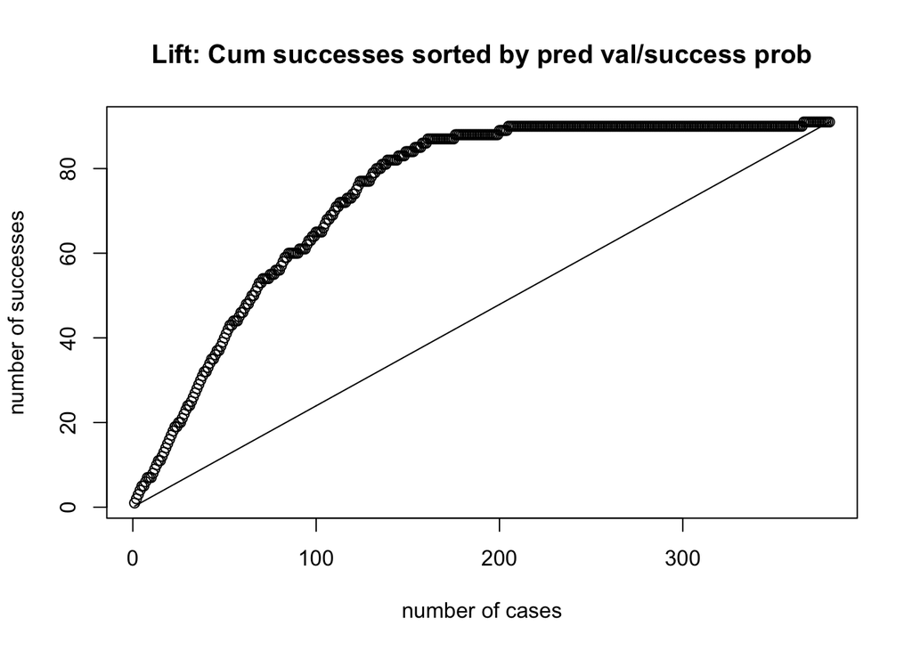

```r
baserate=mean(ytest)
ax=dim(n.test)
ay.base=dim(n.test)
ay.pred=dim(n.test)
ax[1]=1
ay.base[1]=baserate
ay.pred[1]=rank.df1$actual[1]
for (i in 2:n.test) {
  ax[i]=i
  ay.base[i]=baserate*i ## uniformly increase with rate xbar
  ay.pred[i]=ay.pred[i-1]+rank.df1$actual[i]
}

df=cbind(rank.df1,ay.pred,ay.base)
plot(ax,ay.pred,xlab="number of cases",ylab="number of successes",main="Lift: Cum successes sorted by pred val/success prob")
points(ax,ay.base,type="l")
```

```r
'for m2:'
```

```
## [1] "for m2:"
```

```r
'------------'
```

```
## [1] "------------"
```

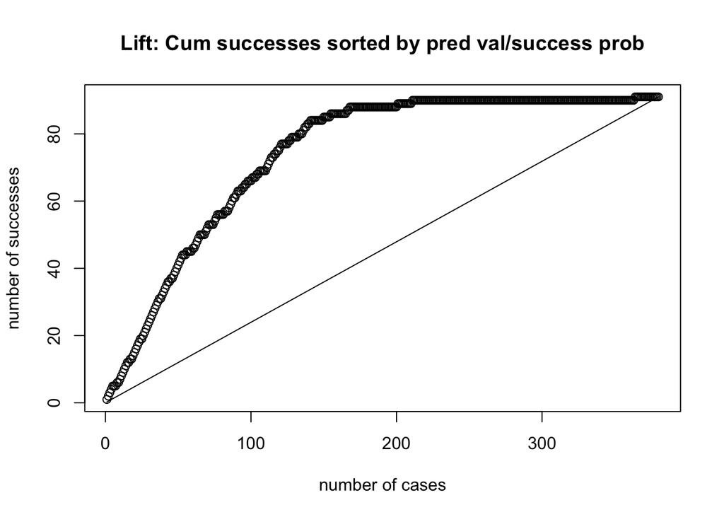

```r
df2=cbind(ptest2,ytest)
rank.df2=as.data.frame(df2[order(ptest2,decreasing=TRUE),])
colnames(rank.df2) = c('predicted','actual')

baserate=mean(ytest)
ax=dim(n.test)
ay.base=dim(n.test)
ay.pred=dim(n.test)
ax[1]=1
ay.base[1]=baserate
ay.pred[1]=rank.df2$actual[1]
for (i in 2:n.test) {
  ax[i]=i
  ay.base[i]=baserate*i ## uniformly increase with rate xbar
  ay.pred[i]=ay.pred[i-1]+rank.df2$actual[i]
}

df=cbind(rank.df2,ay.pred,ay.base)
plot(ax,ay.pred,xlab="number of cases",ylab="number of successes",main="Lift: Cum successes sorted by pred val/success prob")
points(ax,ay.base,type="l")
```

```r
'for m3:'
```

```
## [1] "for m3:"
```

```r
'------------'
```

```
## [1] "------------"
```

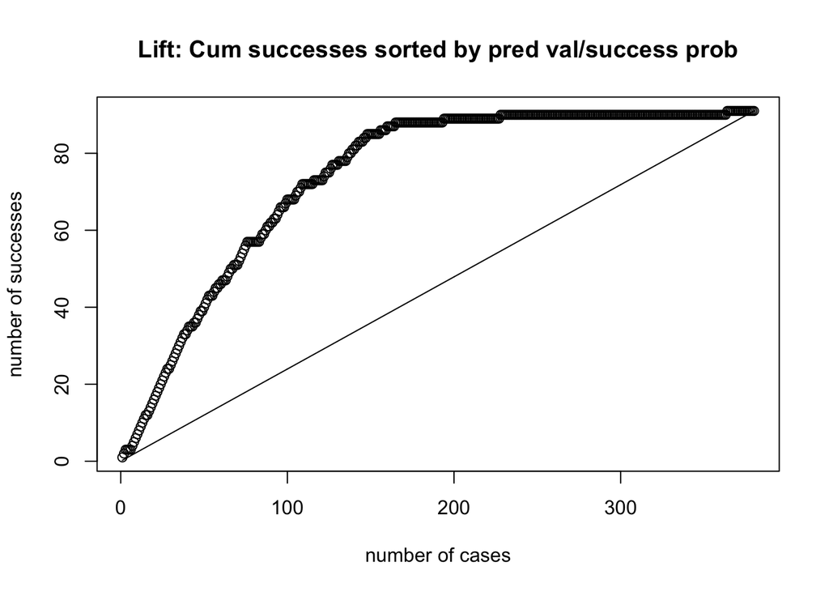

```r
df3=cbind(ptest3,ytest)
rank.df3=as.data.frame(df3[order(ptest3,decreasing=TRUE),])
colnames(rank.df3) = c('predicted','actual')

baserate=mean(ytest)
ax=dim(n.test)
ay.base=dim(n.test)
ay.pred=dim(n.test)
ax[1]=1
ay.base[1]=baserate
ay.pred[1]=rank.df3$actual[1]
for (i in 2:n.test) {
  ax[i]=i
  ay.base[i]=baserate*i ## uniformly increase with rate xbar
  ay.pred[i]=ay.pred[i-1]+rank.df3$actual[i]
}

df=cbind(rank.df3,ay.pred,ay.base)
plot(ax,ay.pred,xlab="number of cases",ylab="number of successes",main="Lift: Cum successes sorted by pred val/success prob")
points(ax,ay.base,type="l")
```

```r
'----------------------end of (*)---------------------'
```

```
## [1] "----------------------end of (*)---------------------"
```

```r
'(a): 10-Fold cross-validation scheme'
```

```
## [1] "(a): 10-Fold cross-validation scheme"
```

```r
'--------------------------------------------------'
```

```
## [1] "--------------------------------------------------"
```

```r
'Split into training and testing:'
```

```
## [1] "Split into training and testing:"
```

```r
set.seed(100)
n.total = length(audit1$ID)
n.total
```

```
## [1] 1897
```

```r
n.train =floor(n.total*0.9)
n.train
```

```
## [1] 1707
```

```r
n.test=n.total - n.train

Xaudit1 <- audit1[,c(2:10)]
Xaudit2 <- audit2[,c(2:8)]
Xaudit3 <- audit3[,c(2:8)]

Xaudit1[1:3,1:3]
```

```
##   Age Employment Education
## 1  38    Private   College
## 2  35    Private Associate
## 3  32    Private    HSgrad
```

```r
Xaudit2[1:3,1:3]
```

```
##   Age Education   Marital
## 1  38   College Unmarried
## 2  35 Associate    Absent
## 3  32    HSgrad  Divorced
```

```r
Xaudit3[1:3,1:3]
```

```
##        Age Education   Marital
## 1 3.637586   College Unmarried
## 2 3.555348 Associate    Absent
## 3 3.465736    HSgrad  Divorced
```

```r
error1 <-c()
error2 <-c()
error3 <-c()

for(i in 1:10)
{
  train=sample(1:n.total, n.train)
  xtrain1 = Xaudit1[train,]
  xtrain2 = Xaudit2[train,]
  xtrain3 = Xaudit3[train,]

  xtest1 = Xaudit1[-train,]
  xtest2 = Xaudit2[-train,]
  xtest3 = Xaudit3[-train,]

  ytrain = audit$TARGET_Adjusted[train]
  ytest = audit$TARGET_Adjusted[-train]
  m1<- glm(TARGET~., family=binomial,data=data.frame(TARGET=ytrain,xtrain1))
  m2<- glm(TARGET~., family=binomial,data=data.frame(TARGET=ytrain,xtrain2))
  m3<- glm(TARGET~., family=binomial,data=data.frame(TARGET=ytrain,xtrain3))

  ptest1 = predict(m1, newdata = data.frame(xtest1), type="response")
  ptest2 = predict(m2, newdata = data.frame(xtest2), type="response")
  ptest3 = predict(m3, newdata = data.frame(xtest3), type="response")

  btest1 = floor(ptest1 + 0.5)
  btest2 = floor(ptest2 + 0.5)
  btest3 = floor(ptest3 + 0.5)

  conf.mat1 = table(ytest,btest1)
  conf.mat2 = table(ytest,btest2)
  conf.mat3 = table(ytest,btest3)

  error1[i] = (conf.mat1[1,2]+conf.mat1[2,1])/n.test
  error2[i] = (conf.mat2[1,2]+conf.mat2[2,1])/n.test
  error3[i] = (conf.mat3[1,2]+conf.mat3[2,1])/n.test

}
mean(error1)
```

```
## [1] 0.1642105
```

```r
mean(error2)
```

```
## [1] 0.1621053
```

```r
mean(error3)
```

```
## [1] 0.1605263
```

The 10-Fold cross-validation was implemented by obtaining 10 random training and test samples (K = 10) from the database. The split between training and test samples was 9:1. Each of the three considered models was estimated with each of K training samples and tested with K testing samples.

The obtained K = 10 errors were computed for each of three models. The mean errors are summarised as follows:

M1:0.1642105 M2:0.1621053 M3:0.1605263

```r
'(b): Odds ratio + Interpretation'
```

```
## [1] "(b): Odds ratio + Interpretation"
```

```r
'--------------------------------------------------'
```

```
## [1] "--------------------------------------------------"
```

```r
mm2 <- glm(TARGET_Adjusted~Age+Education+Marital+Occupation+Income+Deductions+Hours,
           family=binomial(link="logit"),data=audit)
summary(mm2)
```

```
##
## Call:
## glm(formula = TARGET_Adjusted ~ Age + Education + Marital + Occupation +
##     Income + Deductions + Hours, family = binomial(link = "logit"),
##     data = audit)
##
## Deviance Residuals:
##     Min       1Q   Median       3Q      Max
## -2.5622  -0.5335  -0.2220  -0.0002   2.8416
##
## Coefficients:
##                                Estimate Std. Error z value Pr(>|z|)
## (Intercept)                  -6.076e+00  7.373e-01  -8.241  < 2e-16 ***
## Age                           2.775e-02  6.529e-03   4.251 2.13e-05 ***
## EducationBachelor             6.793e-02  3.667e-01   0.185  0.85303
## EducationCollege             -8.399e-01  3.695e-01  -2.273  0.02301 *
## EducationDoctorate            9.671e-01  6.612e-01   1.463  0.14354
## EducationHSgrad              -1.119e+00  3.628e-01  -3.085  0.00203 **
## EducationMaster               4.913e-01  4.451e-01   1.104  0.26963
## EducationPreschool           -1.561e+01  1.393e+03  -0.011  0.99105
## EducationProfessional         1.724e+00  6.600e-01   2.612  0.00901 **
## EducationVocational          -9.941e-01  4.887e-01  -2.034  0.04195 *
## EducationYr10                -1.497e+00  6.589e-01  -2.272  0.02308 *
## EducationYr11                -1.451e+00  7.332e-01  -1.979  0.04784 *
## EducationYr12                -1.652e+00  1.198e+00  -1.380  0.16772
## EducationYr1t4               -1.728e+01  1.725e+03  -0.010  0.99201
## EducationYr5t6               -2.790e+00  1.177e+00  -2.371  0.01773 *
## EducationYr7t8               -1.663e+01  6.074e+02  -0.027  0.97816
## EducationYr9                 -2.922e+00  1.139e+00  -2.567  0.01027 *
## MaritalDivorced              -5.721e-02  3.387e-01  -0.169  0.86588
## MaritalMarried                2.721e+00  2.394e-01  11.364  < 2e-16 ***
## MaritalMarried-spouse-absent  4.246e-01  8.238e-01   0.515  0.60628
## MaritalUnmarried              6.172e-01  5.397e-01   1.144  0.25283
## MaritalWidowed                1.303e-01  6.464e-01   0.202  0.84029
## OccupationClerical            1.111e+00  5.228e-01   2.125  0.03359 *
## OccupationExecutive           1.546e+00  4.932e-01   3.134  0.00172 **
## OccupationFarming            -1.594e-01  6.871e-01  -0.232  0.81652
## OccupationHome               -1.254e+01  1.714e+03  -0.007  0.99416
## OccupationMachinist           4.851e-01  5.407e-01   0.897  0.36957
## OccupationProfessional        1.191e+00  5.160e-01   2.309  0.02096 *
## OccupationProtective          1.765e+00  6.306e-01   2.799  0.00513 **
## OccupationRepair              6.254e-01  4.981e-01   1.256  0.20927
## OccupationSales               9.136e-01  5.104e-01   1.790  0.07342 .
## OccupationService            -4.168e-01  6.260e-01  -0.666  0.50549
## OccupationSupport             1.281e+00  6.081e-01   2.106  0.03521 *
## OccupationTransport           2.127e-01  5.541e-01   0.384  0.70115
## Income                        1.800e-06  1.232e-06   1.460  0.14416
## Deductions                    1.116e-03  2.071e-04   5.391 6.99e-08 ***
## Hours                         3.556e-02  6.643e-03   5.352 8.68e-08 ***
## ---
## Signif. codes:  0 '***' 0.001 '**' 0.01 '*' 0.05 '.' 0.1 ' ' 1
##
## (Dispersion parameter for binomial family taken to be 1)
##
##     Null deviance: 2071.5  on 1896  degrees of freedom
## Residual deviance: 1279.3  on 1860  degrees of freedom
## AIC: 1353.3
##
## Number of Fisher Scoring iterations: 16
```

```r
'Coefficients'
```

```
## [1] "Coefficients"
```

```r
c1=mm2$coefficients['Age']
c2=mm2$coefficients['EducationCollege']
c3=mm2$coefficients['EducationHSgrad']
c4=mm2$coefficients['EducationProfessional']
c5=mm2$coefficients['MaritalMarried']
c6=mm2$coefficients['Deductions']
c7=mm2$coefficients['Hours']

C=c(c1,c2,c3,c4,c5,c6,c7)


'Odds ratios:'
```

```
## [1] "Odds ratios:"
```

```r
o1=exp(mm2$coefficients['Age'])
o2=exp(mm2$coefficients['EducationCollege'])
o3=exp(mm2$coefficients['EducationHSgrad'])
o4=exp(mm2$coefficients['EducationProfessional'])
o5=exp(mm2$coefficients['MaritalMarried'])
o6=exp(mm2$coefficients['Deductions'])
o7=exp(mm2$coefficients['Hours'])

O=c(o1,o2,o3,o4,o5,o6,o7)

for(i in 1:7){
  print(C[i])
  print(O[i])
  }
```

```
##        Age
## 0.02775242
##      Age
## 1.028141
## EducationCollege
##       -0.8399495
## EducationCollege
##        0.4317323
## EducationHSgrad
##       -1.119448
## EducationHSgrad
##       0.3264598
## EducationProfessional
##              1.723856
## EducationProfessional
##              5.606102
## MaritalMarried
##       2.721105
## MaritalMarried
##        15.1971
##  Deductions
## 0.001116423
## Deductions
##   1.001117
##      Hours
## 0.03555809
##    Hours
## 1.036198
```

```r
'------------------------Q3 end--------------------------'
```

```
## [1] "------------------------Q3 end--------------------------"
```

# Task 4

Apply linear and non-linear regression analysis to predict RISK_Adjustment. Evaluate the models through cross-validation and on holdout (leave-one-out or 10-fold cross-validation) samples. Provide details similar to HW1 (3).

```r
dataset_audit<-read.csv("/Users/zhenqiang/Downloads/audit.csv",sep=",",header=TRUE)

# head(dataset_audit,100)
apply(is.na(dataset_audit),2,sum)# find NA values
```

```
##              ID             Age      Employment       Education
##               0               0             100               0
##         Marital      Occupation          Income          Gender
##               0             101               0               0
##      Deductions           Hours RISK_Adjustment TARGET_Adjusted
##               0               0               0               0
```

```r
dataset_audit<-dataset_audit[complete.cases(dataset_audit), ]# delete the NA values
rownames(dataset_audit)<-1:nrow(dataset_audit)# rename rownames
```

```r
apply(is.na(dataset_audit),2,sum)# check NA values
```

```
##              ID             Age      Employment       Education
##               0               0               0               0
##         Marital      Occupation          Income          Gender
##               0               0               0               0
##      Deductions           Hours RISK_Adjustment TARGET_Adjusted
##               0               0               0               0
```

```r
# delete useless features(ID and Target_Adjusted)
dataset_audit<-dataset_audit[,-1]
dataset_audit<-dataset_audit[,-11]

# head(dataset_audit,100)
```

```r
# linear regression model
fit <- lm(dataset_audit$RISK_Adjustment~., dataset_audit)
summary(fit)
```

```
##
## Call:
## lm(formula = dataset_audit$RISK_Adjustment ~ ., data = dataset_audit)
##
## Residuals:
##    Min     1Q Median     3Q    Max
## -15102  -2512   -581    655 103940
##
## Coefficients:
##                                Estimate Std. Error t value Pr(>|t|)
## (Intercept)                   7.341e+02  1.865e+03   0.394   0.6939
## Age                           3.046e+01  1.793e+01   1.699   0.0895 .
## EmploymentPrivate            -1.446e+03  7.148e+02  -2.023   0.0432 *
## EmploymentPSFederal          -1.904e+03  1.196e+03  -1.592   0.1115
## EmploymentPSLocal             9.351e+02  1.041e+03   0.898   0.3692
## EmploymentPSState            -1.708e+03  1.181e+03  -1.447   0.1480
## EmploymentSelfEmp            -1.761e+02  1.124e+03  -0.157   0.8755
## EmploymentVolunteer          -5.034e+03  8.062e+03  -0.624   0.5324
## EducationBachelor            -5.576e+02  1.081e+03  -0.516   0.6061
## EducationCollege             -1.250e+03  1.056e+03  -1.184   0.2366
## EducationDoctorate            1.076e+03  1.967e+03   0.547   0.5844
## EducationHSgrad              -1.614e+03  1.041e+03  -1.551   0.1212
## EducationMaster               1.106e+03  1.316e+03   0.841   0.4006
## EducationPreschool           -2.013e+03  3.443e+03  -0.585   0.5587
## EducationProfessional         8.697e+03  1.975e+03   4.403 1.13e-05 ***
## EducationVocational          -1.711e+03  1.324e+03  -1.292   0.1964
## EducationYr10                 1.678e+02  1.485e+03   0.113   0.9100
## EducationYr11                -1.529e+03  1.420e+03  -1.077   0.2818
## EducationYr12                -1.539e+03  2.290e+03  -0.672   0.5016
## EducationYr1t4               -4.247e+03  3.701e+03  -1.148   0.2513
## EducationYr5t6               -2.934e+03  2.031e+03  -1.445   0.1487
## EducationYr7t8               -2.588e+03  1.735e+03  -1.491   0.1361
## EducationYr9                 -2.616e+03  1.884e+03  -1.388   0.1652
## MaritalDivorced              -7.409e+02  6.538e+02  -1.133   0.2572
## MaritalMarried                2.696e+03  5.211e+02   5.175 2.53e-07 ***
## MaritalMarried-spouse-absent -1.039e+03  1.802e+03  -0.576   0.5645
## MaritalUnmarried             -2.045e+02  1.062e+03  -0.193   0.8473
## MaritalWidowed               -8.559e+02  1.317e+03  -0.650   0.5158
## OccupationClerical            2.651e+01  1.031e+03   0.026   0.9795
## OccupationExecutive           2.250e+02  1.017e+03   0.221   0.8250
## OccupationFarming            -1.977e+03  1.384e+03  -1.428   0.1534
## OccupationHome                2.802e+02  3.675e+03   0.076   0.9392
## OccupationMachinist          -1.107e+03  1.080e+03  -1.025   0.3055
## OccupationMilitary            2.228e+02  8.018e+03   0.028   0.9778
## OccupationProfessional       -7.607e+01  1.093e+03  -0.070   0.9445
## OccupationProtective         -9.043e+02  1.586e+03  -0.570   0.5686
## OccupationRepair             -8.303e+02  1.003e+03  -0.827   0.4081
## OccupationSales              -2.134e+02  1.027e+03  -0.208   0.8354
## OccupationService            -5.591e+02  1.012e+03  -0.552   0.5807
## OccupationSupport             8.752e+02  1.444e+03   0.606   0.5445
## OccupationTransport          -2.142e+03  1.148e+03  -1.866   0.0622 .
## Income                        2.823e-03  3.121e-03   0.905   0.3658
## GenderMale                   -1.814e+02  5.063e+02  -0.358   0.7202
## Deductions                    1.019e+00  5.418e-01   1.881   0.0601 .
## Hours                         3.456e+01  1.712e+01   2.019   0.0436 *
## ---
## Signif. codes:  0 '***' 0.001 '**' 0.01 '*' 0.05 '.' 0.1 ' ' 1
##
## Residual standard error: 7904 on 1854 degrees of freedom
## Multiple R-squared:  0.09845,    Adjusted R-squared:  0.07705
## F-statistic: 4.601 on 44 and 1854 DF,  p-value: < 2.2e-16
```

```r
k <- 0

# LOO-CV function
looCV <- function(x){
  n <- length(dataset_audit$RISK_Adjustment)
  error <- dim(n)
  for(k in 1:n && k != 62){
    # data which row equals 62 has a unique value in Employment. Thus this data cannot be the testing-set.
    train1 <- c(1:n)
    train <- train1[train1 != k] # pick elements that are different with k
    m2 <- lm(x,data = dataset_audit[train,])
    pred <- predict(m2, newdata = dataset_audit[-train,])
    obs <- dataset_audit$RISK_Adjustment[-train]
    error[k] <- obs-pred
  }
me <- mean(error) # mean error
rmse <- sqrt(mean(error^2))
return(rmse) # root mean square error (out-of-sample)
}

# use all features
combine1 <- RISK_Adjustment~.
looCV(combine1)
```

```
## [1] 1185.939
```

```r
# use important features
combine2 <- RISK_Adjustment~Hours+Employment+Education+Marital
looCV(combine2)
```

```
## [1] 1137.087
```

```r
# use important features and not very important features
combine3 <- RISK_Adjustment~Hours+Employment+Education+Marital+Deductions+Occupation+Age
looCV(combine3)
```

```
## [1] 1104.591
```

[output not shown]

```r
# non-linear regression model
poly.fit <- lm(RISK_Adjustment~poly(Age,4)+Employment+Education+Marital+Occupation+poly(Income,1)+Gender+poly(Deductions,3)+poly(Hours,1),dataset_audit)
summary(poly.fit)
```

```
##
## Call:
## lm(formula = RISK_Adjustment ~ poly(Age, 4) + Employment + Education +
##     Marital + Occupation + poly(Income, 1) + Gender + poly(Deductions,
##     3) + poly(Hours, 1), data = dataset_audit)
##
## Residuals:
##    Min     1Q Median     3Q    Max
## -15723  -2524   -611    691 102059
##
## Coefficients:
##                               Estimate Std. Error t value Pr(>|t|)
## (Intercept)                    3965.19    1584.49   2.503   0.0124 *
## poly(Age, 4)1                 17223.66   10350.71   1.664   0.0963 .
## poly(Age, 4)2                -13486.03    9308.43  -1.449   0.1476
## poly(Age, 4)3                -17340.25    8292.25  -2.091   0.0367 *
## poly(Age, 4)4                 16714.34    8127.94   2.056   0.0399 *
## EmploymentPrivate             -1490.08     713.61  -2.088   0.0369 *
## EmploymentPSFederal           -2013.43    1197.18  -1.682   0.0928 .
## EmploymentPSLocal               774.78    1042.43   0.743   0.4574
## EmploymentPSState             -1902.33    1179.18  -1.613   0.1069
## EmploymentSelfEmp              -209.32    1123.53  -0.186   0.8522
## EmploymentVolunteer           -4587.57    8049.45  -0.570   0.5688
## EducationBachelor              -516.88    1081.07  -0.478   0.6326
## EducationCollege              -1358.04    1060.25  -1.281   0.2004
## EducationDoctorate             1061.16    1964.32   0.540   0.5891
## EducationHSgrad               -1682.65    1042.93  -1.613   0.1068
## EducationMaster                 874.09    1314.22   0.665   0.5061
## EducationPreschool            -2247.89    3434.84  -0.654   0.5129
## EducationProfessional          8723.58    1971.64   4.425 1.02e-05 ***
## EducationVocational           -1745.54    1324.05  -1.318   0.1876
## EducationYr10                   -19.35    1487.76  -0.013   0.9896
## EducationYr11                 -2026.04    1449.64  -1.398   0.1624
## EducationYr12                 -2196.25    2315.33  -0.949   0.3430
## EducationYr1t4                -4442.43    3693.44  -1.203   0.2292
## EducationYr5t6                -2861.28    2037.91  -1.404   0.1605
## EducationYr7t8                -2420.53    1736.98  -1.394   0.1636
## EducationYr9                  -2827.03    1886.30  -1.499   0.1341
## MaritalDivorced                -896.89     679.34  -1.320   0.1869
## MaritalMarried                 2537.33     541.12   4.689 2.95e-06 ***
```

[output cut: 13 more lines]

```
## OccupationService              -776.36    1013.34  -0.766   0.4437
## OccupationSupport               694.25    1444.54   0.481   0.6309
## OccupationTransport           -2346.22    1149.25  -2.042   0.0413 *
## poly(Income, 1)                7611.97    9468.48   0.804   0.4215
## GenderMale                      -91.39     506.68  -0.180   0.8569
## poly(Deductions, 3)1          15096.96    8022.90   1.882   0.0600 .
## poly(Deductions, 3)2           3581.19    8037.19   0.446   0.6560
## poly(Deductions, 3)3         -15814.94    8023.14  -1.971   0.0489 *
## poly(Hours, 1)                14425.51    9031.89   1.597   0.1104
## ---
## Signif. codes:  0 '***' 0.001 '**' 0.01 '*' 0.05 '.' 0.1 ' ' 1
##
## Residual standard error: 7882 on 1849 degrees of freedom
## Multiple R-squared:  0.1058, Adjusted R-squared:  0.08214
## F-statistic: 4.466 on 49 and 1849 DF,  p-value: < 2.2e-16
```

```r
# use all features
combine4 <- RISK_Adjustment~poly(Age,4)+Employment+Education+Marital+Occupation+poly(Income,1)+Gender+poly(Deductions,3)+poly(Hours,1)
looCV(combine4)
```

```
## [1] 1148.218
```

```r
# use important features
combine5 <- RISK_Adjustment~poly(Age,4)+Employment+Education+Marital+Occupation+poly(Deductions,3)
looCV(combine5)
```

```
## [1] 225.6285
```

[output not shown]

### Summary

[output not shown]